# Web of science vs arc routing reviews

Elias J. Willemse

12/05/2019

```r
library(tidyverse)
```

```r
library(wordcloud)
```

## Introduction

The main database searched is ‘Web of Science Core Collection’. To check the coverage of the database, the bibliographies of two published arc routing bibliographies, covering [2000-2009](https://doi.org/10.1002/net.20347) and [2010-2017](https://doi.org/10.1002/net.21762) were compared against records from the database found with a key word search `Arc Routing` and then extended to include either `Postman Problem` OR `General Routing Problem` in either the Title, Abstract, Keywords, Keywords Plus of publications, within the same time range of review articles. The following results were obtained. Both the key-word search results for the time periods and the cited papers of the review articles were exported from web-of-science. The results exported and their format were:

- ‘Author’, ‘Title’, ‘Source’
- ‘Tab-delimited (Mac, UTF-8)’

The following results were obtained via web-of-science database searches, compared against the number of articles cited in the coinciding review articles:

- `TOPIC: ("arc routing") Timespan: 2000-2009` returned 128 records compared against the 150 references of the review article (85% coverage).
- `TOPIC: ("arc routing") Timespan: 2010-2017` returned 225 records compared against the 210 references of the review article (107% coverage).

The retrieved citations from web-of-science are available from:

```r
# Review article citations:
rev2000_2009 <- '../data/ar_review_2000_2009.txt'
rev2010_2017 <- '../data/ar_review_2010_2017.txt'

# Records found via 'arc routing' search for time-periods:
search2000_2009 <- '../data/ar_search_ext_2000_2009.txt'
search2010_2017 <- '../data/ar_search_ext_2010_2017.txt'
```

## Data transfomration:

Before conducting the analysis, we first make the files compatible with each other by extracting the minimum required columns and renaming them:

```r
new_columns <- c("author", "title", "journal_book", 'year')

r1 <- read.csv(rev2000_2009, stringsAsFactors = F, sep = '\t', fileEncoding="UTF-8", row.names=NULL)[,c(2, 10, 18, 35)]
r2 <- read.csv(rev2010_2017, stringsAsFactors = F, sep = '\t', fileEncoding="UTF-8", row.names=NULL)[,c(2, 10, 18, 35)]
s1 <- read.csv(search2000_2009, stringsAsFactors = F, sep = '\t', fileEncoding="UTF-8", row.names=NULL)[,c(2, 9, 10, 45)]
s2 <- read.csv(search2010_2017, stringsAsFactors = F, sep = '\t', fileEncoding="UTF-8", row.names=NULL)[,c(2, 9, 10, 45)]

names(r1) <- new_columns
names(r2) <- new_columns
names(s1) <- new_columns
names(s2) <- new_columns
```

## Web of Science review article coverage

The following is the total records cited in the review articles AND indexed on web-of-science:

```
## [1] "Number and fraction articles indexed"
```

```
## [1] 109 175
```

```
## [1] "0.73" "0.83"
```

```
## [1] "Number and fraction of articles not indexed"
```

```
## [1] 41 35
```

```
## [1] "0.27" "0.17"
```

As per the above, quite a few records are not indexed on web-of-science and therefore not included in subsequent analysis. Excluded articles include PhD theses, conference proceedings, technical reports, a few books, pre-2000 articles, and non-indexed journals.

## Review 1 compared to search 1

Next, we analyse the number of articles included in both the review articles and web-of-science search, and excluded by either. First, we compare the first review article:

```
## [1] "Articles in both: 76"
```

```
## [1] "Articles in review 1 AND NOT in search 1: 33"
```

```
## [1] "Articles in search 1 AND NOT in review 1: 154"
```

We repeat the analysis, filtering out records from the review article published before the review period:

```
## [1] "Articles in both: 76"
```

```
## [1] "Articles in review 1 AND NOT in search 1: 5"
```

```
## [1] "Articles in search 1 AND NOT in review 1: 154"
```

First we look at the title’s of articles in the review but not in the search results:

```
## [1] "Leonhard Euler: A brief appreciation"
## [2] "On the separation of maximally violated mod-k cuts"
## [3] "Generalized Steiner problems and other variants"
## [4] "Robust branch-and-cut-and-price for the capacitated vehicle routing problem"
## [5] "A faster exact separation algorithm for blossom inequalities"
```

Articles included in the review but not the search mostly focus on problem variants that do not include any of the keywords in the titles of the articles; they seem to focus on other problems though they may be related to arc routing problems.

Next we look at articles in the search results but not the review:

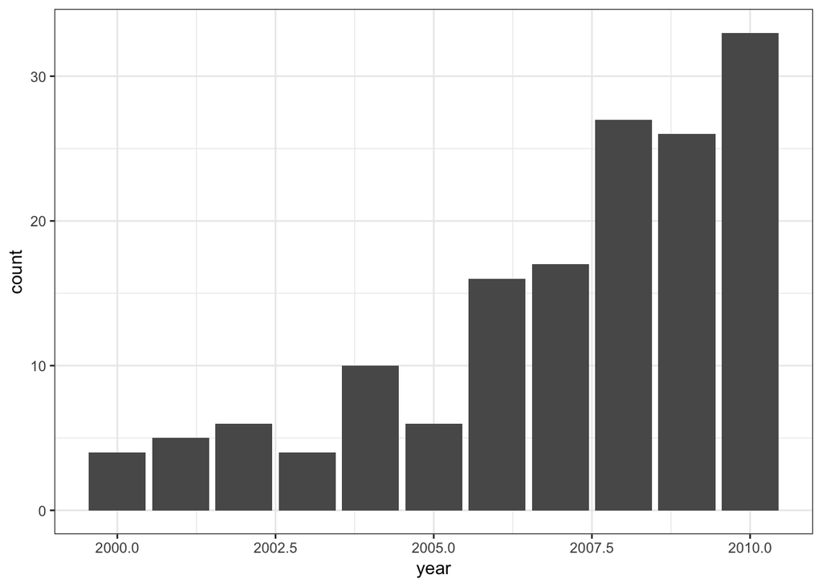

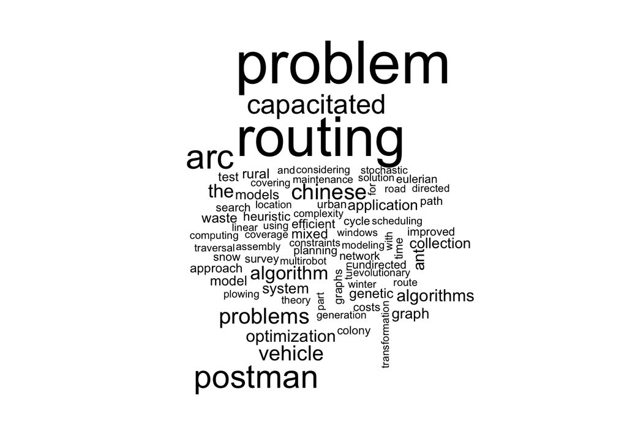

[figure not shown]

Articles included in the search but not the review include a number of articles published in 2010 directly after the review article; and quite a few articles in conference proceedings, IEEE and other non-traditional arc routing journals.

## Review 2 compared to search 2

And then the second review article:

```
## [1] "Articles in both: 152"
```

```
## [1] "Articles in review 2 AND NOT in search 2: 23"
```

```
## [1] "Articles in search 2 AND NOT in review 2: 169"
```

We repeat the analysis, filtering out records from the review article published before the review period:

```
## [1] "Articles in both: 152"
```

```
## [1] "Articles in review 2 AND NOT in search 2: 23"
```

```
## [1] "Articles in search 2 AND NOT in review 2: 169"
```

First we look at the title’s of articles in the review but not in the search results:

```
##  [1] "A Routing and Waste Collection Case-Study"
##  [2] "A survey of recent research on location-routing problems"
##  [3] "A taxonomical analysis, current methods and objectives on location-routing problems"
##  [4] "Advances in Vehicle Routing for Snow Plowing"
##  [5] "BeiDou Satellites Assistant Determination by Receiving Other GNSS Downlink Signals"
##  [6] "City-courier routing and scheduling problems"
##  [7] "Coordinating debris cleanup operations in post disaster road networks"
##  [8] "From Few Components to an Eulerian Graph by Adding Arcs"
##  [9] "Hybrid metaheuristics for the profitable arc tour problem"
## [10] "Model of debris collection operation after disasters and its application in urban area"
## [11] "Municipal Solid Waste Collection and Management Problems: A Literature Review"
## [12] "Order-first split-second methods for vehicle routing problems: A review"
## [13] "Orienteering Problem: A survey of recent variants, solution approaches and applications"
## [14] "Parameterized Complexity of Eulerian Deletion Problems"
## [15] "Parameterized Complexity of Eulerian Deletion Problems"
## [16] "Response and recovery after severe wind storms using hierarchical open vehicle routing"
## [17] "Route Optimization for Meter Reading and Salt Spreading"
## [18] "Routing in Waste Collection Applications"
## [19] "Solution methodologies for debris removal in disaster response"
## [20] "The hierarchical traveling salesman problem"
## [21] "The orienteering problem: A survey"
## [22] "The planning of cycle trips in the province of East Flanders"
## [23] "Towards the Emergency for Green Networking with Robust Algorithm"
```

Same as review 1, articles included in the review but not the search focus on problem variants that do not include any of the keywords in the titles of the articles, or they focus on specific arc routing applications, such as waste collection, meter reading, debris removal, etc.

Next, we look at articles in the search but not the review:

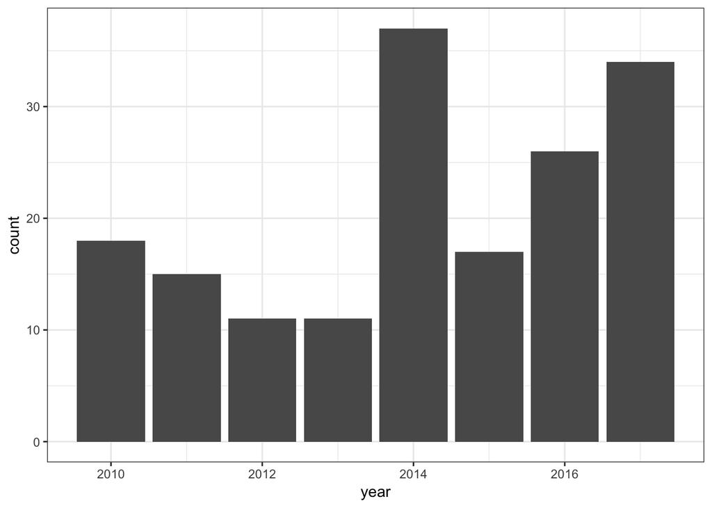

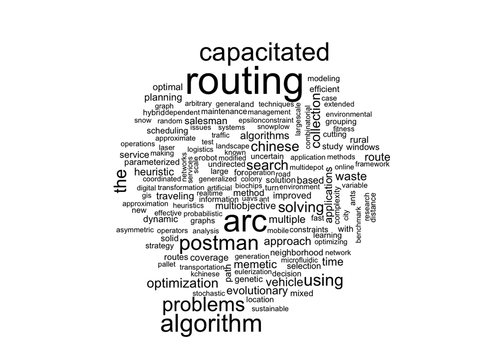

[figure not shown]

Articles included in the search but not the review again include a number of articles published in 2017 directly after the review article; and quite a few articles in conference proceedings, and other non-traditional arc routing journals.

## Combined review 1 and 2 compared to combined search 1 and 2

Finally, we combined and compare the results of both the reviews and search results:

```
## [1] "Articles in both: 243"
```

```
## [1] "Articles in review AND NOT in search : 28"
```

```
## [1] "Articles in search AND NOT in review : 308"
```

```
##  [1] "A faster exact separation algorithm for blossom inequalities"
##  [2] "A Routing and Waste Collection Case-Study"
##  [3] "A survey of recent research on location-routing problems"
##  [4] "A taxonomical analysis, current methods and objectives on location-routing problems"
##  [5] "Advances in Vehicle Routing for Snow Plowing"
##  [6] "BeiDou Satellites Assistant Determination by Receiving Other GNSS Downlink Signals"
##  [7] "City-courier routing and scheduling problems"
##  [8] "Coordinating debris cleanup operations in post disaster road networks"
##  [9] "From Few Components to an Eulerian Graph by Adding Arcs"
## [10] "Generalized Steiner problems and other variants"
## [11] "Hybrid metaheuristics for the profitable arc tour problem"
## [12] "Leonhard Euler: A brief appreciation"
## [13] "Model of debris collection operation after disasters and its application in urban area"
## [14] "Municipal Solid Waste Collection and Management Problems: A Literature Review"
## [15] "On the separation of maximally violated mod-k cuts"
## [16] "Order-first split-second methods for vehicle routing problems: A review"
## [17] "Orienteering Problem: A survey of recent variants, solution approaches and applications"
## [18] "Parameterized Complexity of Eulerian Deletion Problems"
## [19] "Parameterized Complexity of Eulerian Deletion Problems"
## [20] "Response and recovery after severe wind storms using hierarchical open vehicle routing"
## [21] "Robust branch-and-cut-and-price for the capacitated vehicle routing problem"
## [22] "Route Optimization for Meter Reading and Salt Spreading"
## [23] "Routing in Waste Collection Applications"
## [24] "Solution methodologies for debris removal in disaster response"
## [25] "The hierarchical traveling salesman problem"
## [26] "The orienteering problem: A survey"
## [27] "The planning of cycle trips in the province of East Flanders"
## [28] "Towards the Emergency for Green Networking with Robust Algorithm"
```

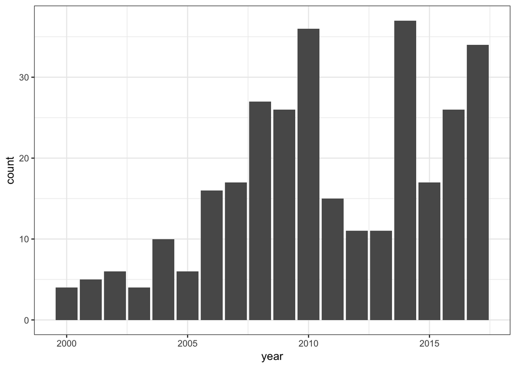

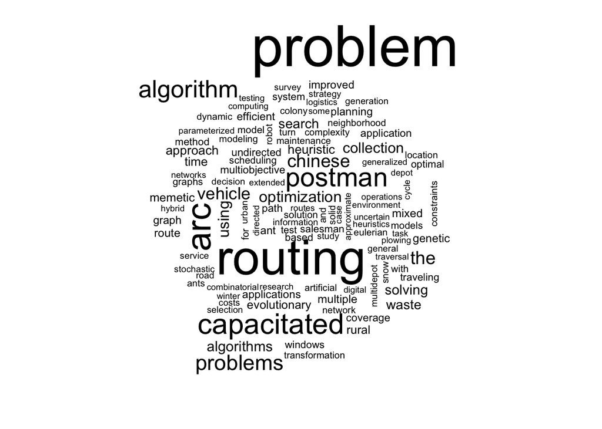

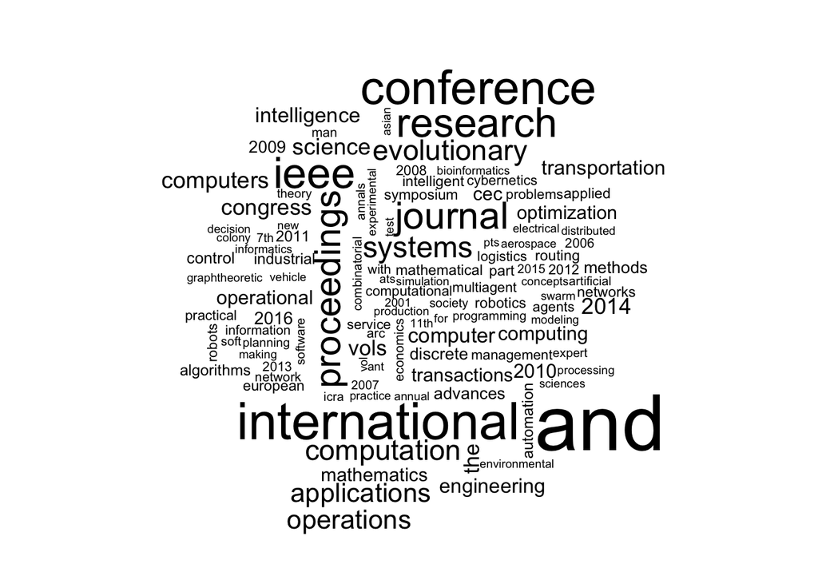

## Conclusion

The review articles focus more on journal articles, whereas the search results include conference proceedings and are therefore more comprehensive. A number of articles reviewed are not indexed on Web-of-Science. Overall, using web-of-science should give fairly comprehensive search results on arc routing problems and their variants up to the current point of time.